# Webinar EFI – Exploring SpaDES

Tati Micheletti

2024-04-12

This is a document with changes to be made during the presentation of *SpaDES: a tool to PERFICT your workflow*, on April 15th, 2024. The presentation is available on [YouTube](https://www.youtube.com/watch?v=sjE6j9Mw_K8) and on the [ESA/EFI Statistical Methods Seminar Series](https://ecoforecast.org/workshops/statistical-methods-seminar-series/#details).

During the presentation, we will download and run an integrated project (demo.R), and check the results and dive into the modules using the current document as a guide.

This document is available at: https://tinyurl.com/webinarEFI2/

## 1. Exploring the results from the simulation

Once the simulation from demo.R has ran, we can explore the results. Using `completed()` we can observe the list of completed events, their times, type, start and end clock time.

```r
> SpaDES.core::completed(results)
    eventTime         moduleName            eventType eventPriority ._prevEventTimeFinish           clockTime
        <num>             <char>               <char>         <num>                <POSc>              <POSc>
 1:      2013         checkpoint                 init             0   2024-04-12 13:46:14 2024-04-12 13:46:14
 2:      2013               save                 init             0   2024-04-12 13:46:14 2024-04-12 13:46:14
 3:      2013           progress                 init             0   2024-04-12 13:46:14 2024-04-12 13:46:14
 4:      2013               load                 init             0   2024-04-12 13:46:14 2024-04-12 13:46:14
 5:      2013   speciesAbundance                 init             1   2024-04-12 13:46:14 2024-04-12 13:46:14
 6:      2013        temperature                 init             1   2024-04-12 13:46:14 2024-04-12 13:46:14
 7:      2013 speciesAbundTempLM                 init             1   2024-04-12 13:46:14 2024-04-12 13:46:15
 8:      2013   speciesAbundance       tableToRasters             5   2024-04-12 13:46:15 2024-04-12 13:46:15
 9:      2013   speciesAbundance                 plot             5   2024-04-12 13:46:15 2024-04-12 13:46:15
10:      2013        temperature         dataToRaster             5   2024-04-12 13:46:15 2024-04-12 13:46:15
11:      2013        temperature             plotting             5   2024-04-12 13:46:15 2024-04-12 13:46:15
12:      2013 speciesAbundTempLM        tableBuilding             5   2024-04-12 13:46:15 2024-04-12 13:46:15
13:      2014   speciesAbundance       tableToRasters             5   2024-04-12 13:46:15 2024-04-12 13:46:15
14:      2014        temperature         dataToRaster             5   2024-04-12 13:46:15 2024-04-12 13:46:15
15:      2014 speciesAbundTempLM        tableBuilding             5   2024-04-12 13:46:15 2024-04-12 13:46:15
16:      2015   speciesAbundance       tableToRasters             5   2024-04-12 13:46:15 2024-04-12 13:46:15
17:      2015        temperature         dataToRaster             5   2024-04-12 13:46:15 2024-04-12 13:46:15
18:      2015 speciesAbundTempLM        tableBuilding             5   2024-04-12 13:46:15 2024-04-12 13:46:15
19:      2016   speciesAbundance       tableToRasters             5   2024-04-12 13:46:15 2024-04-12 13:46:15
20:      2016        temperature         dataToRaster             5   2024-04-12 13:46:15 2024-04-12 13:46:15
21:      2016 speciesAbundTempLM        tableBuilding             5   2024-04-12 13:46:15 2024-04-12 13:46:15
22:      2017   speciesAbundance       tableToRasters             5   2024-04-12 13:46:15 2024-04-12 13:46:15
23:      2017        temperature         dataToRaster             5   2024-04-12 13:46:15 2024-04-12 13:46:15
24:      2017 speciesAbundTempLM        tableBuilding             5   2024-04-12 13:46:15 2024-04-12 13:46:15
25:      2018   speciesAbundance                 plot             5   2024-04-12 13:46:15 2024-04-12 13:46:15
26:      2018   speciesAbundance       tableToRasters             5   2024-04-12 13:46:15 2024-04-12 13:46:15
27:      2018        temperature         dataToRaster             5   2024-04-12 13:46:15 2024-04-12 13:46:15
28:      2018 speciesAbundTempLM        tableBuilding             5   2024-04-12 13:46:15 2024-04-12 13:46:15
29:      2019   speciesAbundance       tableToRasters             5   2024-04-12 13:46:15 2024-04-12 13:46:15
30:      2019        temperature         dataToRaster             5   2024-04-12 13:46:15 2024-04-12 13:46:15
31:      2019 speciesAbundTempLM        tableBuilding             5   2024-04-12 13:46:15 2024-04-12 13:46:15
32:      2020   speciesAbundance       tableToRasters             5   2024-04-12 13:46:15 2024-04-12 13:46:16
33:      2020        temperature         dataToRaster             5   2024-04-12 13:46:16 2024-04-12 13:46:16
34:      2020 speciesAbundTempLM        tableBuilding             5   2024-04-12 13:46:16 2024-04-12 13:46:16
35:      2021   speciesAbundance       tableToRasters             5   2024-04-12 13:46:16 2024-04-12 13:46:16
36:      2021        temperature         dataToRaster             5   2024-04-12 13:46:16 2024-04-12 13:46:16
37:      2021 speciesAbundTempLM        tableBuilding             5   2024-04-12 13:46:16 2024-04-12 13:46:16
38:      2022   speciesAbundance       tableToRasters             5   2024-04-12 13:46:16 2024-04-12 13:46:16
39:      2022        temperature         dataToRaster             5   2024-04-12 13:46:16 2024-04-12 13:46:16
40:      2022 speciesAbundTempLM        tableBuilding             5   2024-04-12 13:46:16 2024-04-12 13:46:16
41:      2023        temperature             plotting             5   2024-04-12 13:46:16 2024-04-12 13:46:16
42:      2023        temperature         dataToRaster             5   2024-04-12 13:46:16 2024-04-12 13:46:16
43:      2023 speciesAbundTempLM        tableBuilding             5   2024-04-12 13:46:16 2024-04-12 13:46:16
44:      2023 speciesAbundTempLM        modelBuilding             5   2024-04-12 13:46:16 2024-04-12 13:46:16
45:      2023 speciesAbundTempLM abundanceForecasting             5   2024-04-12 13:46:16 2024-04-12 13:46:16
46:      2023 speciesAbundTempLM                 plot             5   2024-04-12 13:46:16 2024-04-12 13:46:16
47:      2024        temperature         dataToRaster             5   2024-04-12 13:46:16 2024-04-12 13:46:16
48:      2024 speciesAbundTempLM abundanceForecasting             5   2024-04-12 13:46:16 2024-04-12 13:46:17
49:      2024 speciesAbundTempLM                 plot             5   2024-04-12 13:46:17 2024-04-12 13:46:17
50:      2025        temperature         dataToRaster             5   2024-04-12 13:46:17 2024-04-12 13:46:17
51:      2025 speciesAbundTempLM abundanceForecasting             5   2024-04-12 13:46:17 2024-04-12 13:46:17
52:      2025 speciesAbundTempLM                 plot             5   2024-04-12 13:46:17 2024-04-12 13:46:17
53:      2026        temperature         dataToRaster             5   2024-04-12 13:46:17 2024-04-12 13:46:17
54:      2026 speciesAbundTempLM abundanceForecasting             5   2024-04-12 13:46:17 2024-04-12 13:46:17
55:      2026 speciesAbundTempLM                 plot             5   2024-04-12 13:46:17 2024-04-12 13:46:17
56:      2027        temperature         dataToRaster             5   2024-04-12 13:46:17 2024-04-12 13:46:17
57:      2027 speciesAbundTempLM abundanceForecasting             5   2024-04-12 13:46:17 2024-04-12 13:46:17
58:      2027 speciesAbundTempLM                 plot             5   2024-04-12 13:46:17 2024-04-12 13:46:17
59:      2028        temperature         dataToRaster             5   2024-04-12 13:46:17 2024-04-12 13:46:17
60:      2028 speciesAbundTempLM abundanceForecasting             5   2024-04-12 13:46:17 2024-04-12 13:46:17
61:      2028 speciesAbundTempLM                 plot             5   2024-04-12 13:46:17 2024-04-12 13:46:17
62:      2029        temperature         dataToRaster             5   2024-04-12 13:46:17 2024-04-12 13:46:17
63:      2029 speciesAbundTempLM abundanceForecasting             5   2024-04-12 13:46:17 2024-04-12 13:46:18
64:      2029 speciesAbundTempLM                 plot             5   2024-04-12 13:46:18 2024-04-12 13:46:18
65:      2030        temperature         dataToRaster             5   2024-04-12 13:46:18 2024-04-12 13:46:18
66:      2030 speciesAbundTempLM abundanceForecasting             5   2024-04-12 13:46:18 2024-04-12 13:46:18
67:      2030 speciesAbundTempLM                 plot             5   2024-04-12 13:46:18 2024-04-12 13:46:18
68:      2031        temperature         dataToRaster             5   2024-04-12 13:46:18 2024-04-12 13:46:18
69:      2031 speciesAbundTempLM abundanceForecasting             5   2024-04-12 13:46:18 2024-04-12 13:46:18
70:      2031 speciesAbundTempLM                 plot             5   2024-04-12 13:46:18 2024-04-12 13:46:18
71:      2032        temperature         dataToRaster             5   2024-04-12 13:46:18 2024-04-12 13:46:18
72:      2032 speciesAbundTempLM abundanceForecasting             5   2024-04-12 13:46:18 2024-04-12 13:46:18
73:      2032 speciesAbundTempLM                 plot             5   2024-04-12 13:46:18 2024-04-12 13:46:18
    eventTime         moduleName            eventType eventPriority ._prevEventTimeFinish           clockTime
```

We can also see how modules and objects interact using the functions `objectDiagram()` and `moduleDiagram()`.

```r
SpaDES.core::moduleDiagram(results)
```

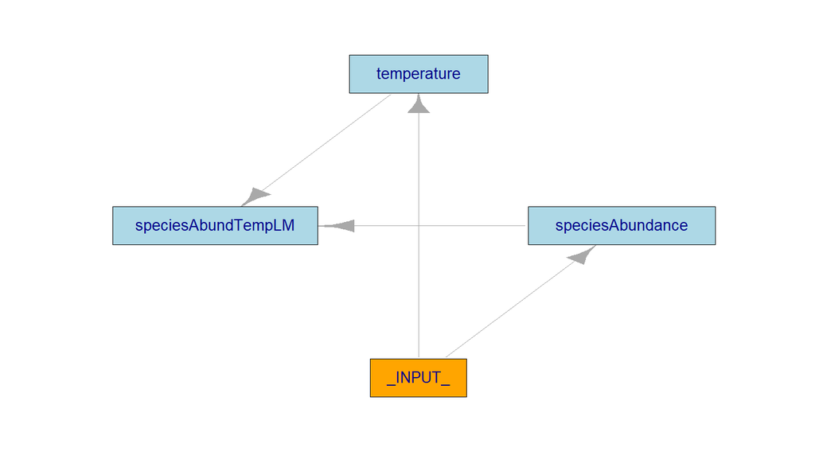

Figure 1. Modules’ diagram showing the interactions among modules.

```r
SpaDES.core::objectDiagram(results)
```

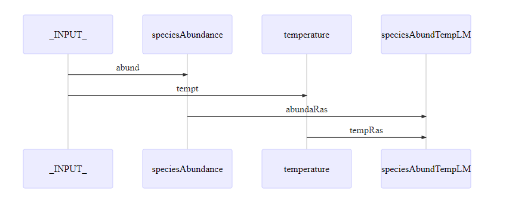

Figure 2. Object diagram showing the interactions among modules through objects.

Accessing the forecasted abundances and the difference raster is also possible. This is done by calling the `object` name from the `results` list.

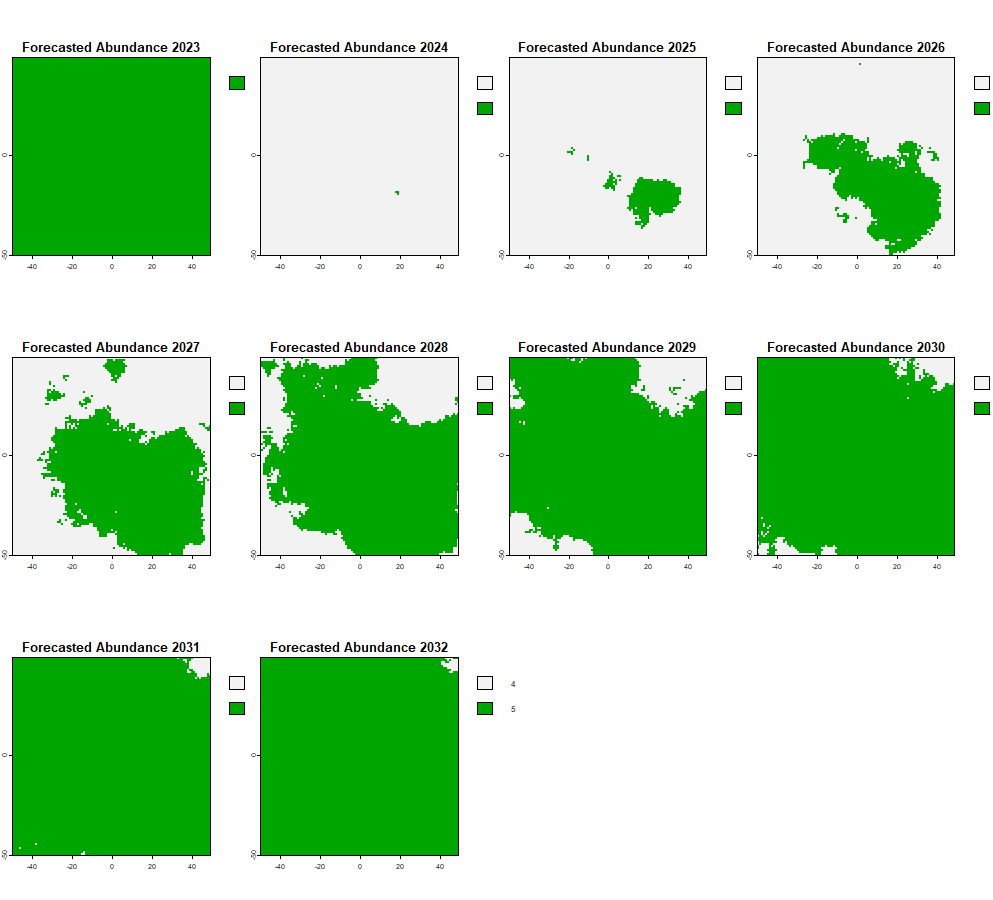

Figure 3. Forecasted abundances from 2023 to 2032.

```r
terra::plot(rast(results$forecasts))
```

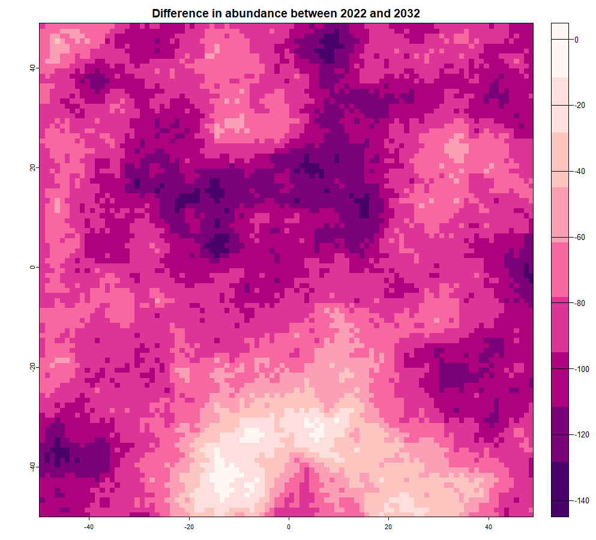

Figure 4. Calculated difference in abundance between 2022 and 2032.

```r
terra::plot(results$forecastedDifferences, col = c("#49006A", "#7A0177", "#AE017E",
                                                   "#DD3497", "#F768A1", "#FA9FB5",
                                                   "#FCC5C0", "#FDE0DD", "#FFF7F3"))
```

## 2. Add a validation module to make it more PERFICT

To add another module to our project, for example, an evaluation one, we simply need to add the following line `"tati-micheletti/evaluateLM@main"` to the setupProject call (in the modules’ list) and re-run it. The call should look like this:

```r
Setup <- SpaDES.project::setupProject(

  paths = list(projectPath = "integratingSpaDESmodules",
               modulePath = "SpaDES_Modules",
               outputPath = "outputs"),

  modules = c("tati-micheletti/speciesAbundance@main",
              "tati-micheletti/temperature@main",
              "tati-micheletti/speciesAbundTempLM@main",
              "tati-micheletti/evaluateLM@main"), # <~~ Here we added the new module

  times = list(start = 2013,
               end = 2032),

  Restart = TRUE
)
```

```r
$summary

Call:  glm(formula = abundance ~ temperature, family = "poisson", data = sim$modDT)

Coefficients:
(Intercept)  temperature
    3.06226      0.04636

Degrees of Freedom: 98009 Total (i.e. Null);  98008 Residual
Null Deviance:      985100
Residual Deviance: 916100   AIC: 1496000

$crossValidation

Linear Regression

98010 samples
    1 predictor

No pre-processing
Resampling: Cross-Validated (20 fold)
Summary of sample sizes: 93109, 93109, 93109, 93110, 93109, 93110, ...
Resampling results:

  RMSE      Rsquared    MAE
  23.93154  0.07304125  19.47062

Tuning parameter 'intercept' was held constant at a value of TRUE
```

We can also see the Q-Q Plot:

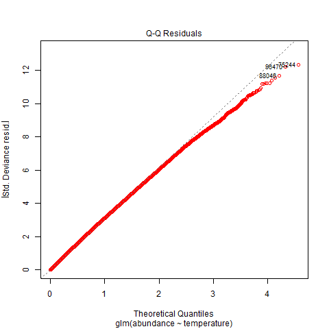

And the residuals vs fitted values plot:

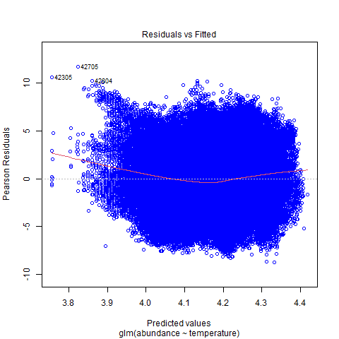

## 3. Remove modules without breaking the workflow

We can also remove modules, and test different combinations of modules without breaking the workflow. We can test, for example, the module `speciesAbundace` alone:

```r
Setup <- SpaDES.project::setupProject(

  paths = list(projectPath = "integratingSpaDESmodules",
               modulePath = "SpaDES_Modules",
               outputPath = "outputs"),

  modules = "tati-micheletti/speciesAbundance@main", # <~~ Here we run only one module

  times = list(start = 2013,
               end = 2032),

  Restart = TRUE
)
```

## 4. Testing, testing, testing

We can also observe the module tests located in the folder: `~/integratingSpaDESmodules/SpaDES_Modules/speciesAbundance/tests` all tests can be run by running the script `~/integratingSpaDESmodules/SpaDES_Modules/speciesAbundance/tests/unitTests.R`.

```r
> # to test all the test files in the tests folder:
> source(file.path(getwd(), "SpaDES_Modules/speciesAbundance/tests/testthat/test-fullModule.R"))
Test passed
```

## 5. Modifying an existing Module

Finally, we can reuse modules by modifying their code. Here we will create a new function to add to the module `speciesAbundance`.

### 5.1. Create the function and add it to the module

It is important to highlight that the function may be places in the module, or in a script in the module’s `R` folder.

```r
modelAbundTime <- function(abundanceData){
  modAbund <- lm(formula = abundance ~ years, data = abundanceData)
  summary(modAbund)
  return(modAbund)
}
```

### 5.2. Add the event to the module

Now we need to add the event that will run our function to the module. For that, it helps copying an event and just changing the code.

```r
  abundanceThroughTime = {

  sim$modAbund <- modelAbundTime(abundanceData = sim$abund)

  # No need to schedule further events as this one happens at the end of the
  # module's data
}
```

Note that, alternatively, we could have directly added the block of code to the event as below, without creating the function. The drawback is that once more complexity is added, the code becomes long and harder to follow.

```r
  abundanceThroughTime = {

  modAbund <- lm(formula = abundance ~ years, data = sim$abund)
  sim$modAbund <- summary(modAbund)


  # No need to schedule further events as this one happens at the end of the
  # module's data
}
```

### 5.3. Schedule the event `abundanceThroughTime` in the `init` event

In order for our new event to run, we need to schedule it in the `init` event. An `init` event is the only mandatory in all modules. We will schedule our event to the last year of the project run.

```r
sim <- scheduleEvent(sim, end(sim), "speciesAbundance", "abundanceThroughTime")
```

### 5.4. Declare `modAbund` as a createdOutput

```r
createsOutput(objectName = "modAbund", objectClass = "lm",
              desc = paste0("A fitted model (of the `lm` class) of abundance through time"))
```

Now you can re-run the project and see the results from the added event. You can access the new object created (`modAbund`) in the same way we accessed the forecasts earlier:

```r
> results$modAbund

Call:
lm(formula = abundance ~ years, data = sim$abund)

Residuals:
    Min      1Q  Median      3Q     Max
-77.487 -16.566   0.277  17.042  72.513

Coefficients:
              Estimate Std. Error t value Pr(>|t|)
(Intercept) -5.830e+03  5.249e+01  -111.1   <2e-16 ***
years        2.922e+00  2.602e-02   112.3   <2e-16 ***
---
Signif. codes:  0 ‘***’ 0.001 ‘**’ 0.01 ‘*’ 0.05 ‘.’ 0.1 ‘ ’ 1

Residual standard error: 23.4 on 98008 degrees of freedom
Multiple R-squared:  0.114, Adjusted R-squared:  0.114
F-statistic: 1.261e+04 on 1 and 98008 DF,  p-value: < 2.2e-16
```

### Challenge!

Now try changing the module yourself. Add, for example, the function below to the **existing** event named `plot`, plotting the data in the first (2013) and the last (2022) years (the answer can be found [here](https://github.com/tati-micheletti/EFI_webinar/blob/main/liveChanges.R#L124-L145)):

```r
plotAbundance <- function(abundanceData, yearsToPlot){
  Sys.sleep(1.2) # To ensure we will see the results from the previous plot
  dataplot <- abundanceData[years %in% yearsToPlot,]
  abundData <- Copy(dataplot)
  abundData[, years := as.factor(years)]
  abundData[, averageYear := mean(abundance), by = "years"]
  pa <- ggplot(data = abundData, aes(x = abundance, group=years, color=years, fill = years)) +
    geom_histogram(binwidth=5) +
    facet_grid(years ~ .) +
    geom_vline(data = unique(abundData[, c("years", "averageYear")]),
               aes(xintercept = averageYear),
               linetype="dashed", color = "black") +
    theme(legend.position = "none")
  print(pa)
  return(pa)
}
```